# PSY 8960 Final Project

# Analysis

I chose to analyze this dataset using discriminant analysis as this is a classification problem. I found two different algorithms that seemed promising. The first is a high-dimensional discriminant analysis. Even though this problem isn’t truly high dimensional in the way that a neuroimaging study or genomics study might be, it is still fairly large, and I thought it might yield good results. The second approach is a penalized discriminant analysis. I thought that this might be appropriate since penalization can help to reduce dimensionality. My plan is to compare the accuracy of the two models using 10 fold cross-validation and the accuracy on a holdout sample to see which model provides better results. I also chose to parallelize this part of the code to improve the speed of the code.

```r
# Chosen to be about 10% of the total sample
holdout.size <- 900

# Create a holdout and training sample
set.seed(7)
rows <- sample(x = nrow(mbti_combined), size = holdout.size, replace = F)
holdout <- mbti_combined[rows,]
training <- mbti_combined[-rows, ]

# create 10 folds so that folds will be the same for all methods used
folds <-  createFolds(training$MBTI_type, 10)

cl <- makeCluster(detectCores() - 1)
registerDoParallel(cl)

# Run high-dimensional discriminant analysis and compute 10-fold cv statistics
hdda_model <- train(MBTI_type ~ .,
                    data = training,
                    method = "hdda",
                    trControl = trainControl(method = "cv",
                                             indexOut = folds,
                                             verboseIter = F)
)

hdda_model
```

```
## High Dimensional Discriminant Analysis
##
## 7774 samples
## 1036 predictors
##   16 classes: 'ENFJ', 'ENFP', 'ENTJ', 'ENTP', 'ESFJ', 'ESFP', 'ESTJ', 'ESTP', 'INFJ', 'INFP', 'INTJ', 'INTP', 'ISFJ', 'ISFP', 'ISTJ', 'ISTP'
##
## No pre-processing
## Resampling: Cross-Validated (10 fold)
## Summary of sample sizes: 6998, 6995, 6996, 6998, 6997, 6997, ...
## Resampling results across tuning parameters:
##
##   threshold  Accuracy   Kappa
##   0.050      0.6280017  0.5775199
##   0.175      0.6053539  0.5522526
##   0.300      0.6053539  0.5522526
##
## Tuning parameter 'model' was held constant at a value of all
## Accuracy was used to select the optimal model using the largest value.
## The final values used for the model were threshold = 0.05 and model = all.
```

```r
# Calculate holdout performance - accuracy
hdda_holdout <- predict(hdda_model, holdout)
hdda_confusion <- table(holdout$MBTI_type, hdda_holdout)
hdda_confusion
```

```
##       hdda_holdout
##        ENFJ ENFP ENTJ ENTP ESFJ ESFP ESTJ ESTP INFJ INFP INTJ INTP ISFJ ISFP
##   ENFJ   14    4    1    0    0    0    0    0    3    2    1    1    0    2
##   ENFP    1   45    2    3    0    2    0    0    5    5    8    6    0    5
##   ENTJ    0    0   10    2    0    0    0    1    1    3    2    3    0    1
##   ENTP    1    4    1   37    0    1    0    2    4    1    2    8    0    0
##   ESFJ    0    0    0    0    0    0    0    0    0    0    0    0    0    0
##   ESFP    0    0    0    0    0    2    0    0    0    1    0    0    0    2
##   ESTJ    0    0    1    0    0    0    3    0    0    0    0    0    0    0
##   ESTP    0    0    0    1    0    0    0    5    0    0    1    1    0    2
##   INFJ    6    5    1    2    0    1    0    4   84   24    7    7    2    3
##   INFP    3    7    2    1    0    3    1    3    9  128    6    9    2    7
##   INTJ    0    2    4    3    0    0    0    2    5    5   65   18    0    5
##   INTP    2    0    2    3    1    0    2    0    5   11    1   83    1    5
##   ISFJ    0    0    0    0    0    0    0    0    2    2    0    2    9    2
##   ISFP    1    0    1    0    0    0    0    1    0    5    0    1    0    8
##   ISTJ    0    0    0    1    0    0    0    1    0    1    2    2    1    0
##   ISTP    0    0    0    1    0    0    1    2    1    1    0    5    0    2
##       hdda_holdout
##        ISTJ ISTP
##   ENFJ    0    0
##   ENFP    2    2
##   ENTJ    0    0
##   ENTP    0    3
##   ESFJ    0    1
##   ESFP    0    1
##   ESTJ    0    0
##   ESTP    0    0
##   INFJ    3    3
##   INFP    4    1
##   INTJ    4    2
##   INTP    2    4
##   ISFJ    0    2
##   ISFP    0    1
##   ISTJ    9    2
##   ISTP    0   34
```

```r
hdda_accuracy <- sum(diag(hdda_confusion))/holdout.size
hdda_accuracy
```

```
## [1] 0.5955556
```

```r
stopCluster(cl)
registerDoSEQ()
```

```r
# Run second model to see if accuracy improves

cl <- makeCluster(detectCores() - 1)
registerDoParallel(cl)

# Run sparse LDA and compute 10-fold cv statistics
pda_model <- train(MBTI_type ~ .,
                     data = training,
                     method = "pda",
                     trControl = trainControl(method = "cv",
                                              indexOut = folds,
                                              verboseIter = T)
)
pda_model
```

```
## Penalized Discriminant Analysis
##
## 7774 samples
## 1036 predictors
##   16 classes: 'ENFJ', 'ENFP', 'ENTJ', 'ENTP', 'ESFJ', 'ESFP', 'ESTJ', 'ESTP', 'INFJ', 'INFP', 'INTJ', 'INTP', 'ISFJ', 'ISFP', 'ISTJ', 'ISTP'
##
## No pre-processing
## Resampling: Cross-Validated (10 fold)
## Summary of sample sizes: 6998, 6996, 6995, 6997, 6996, 6996, ...
## Resampling results across tuning parameters:
##
##   lambda  Accuracy   Kappa
##   0e+00   0.7853092  0.7525752
##   1e-04   0.7853092  0.7525752
##   1e-01   0.7853092  0.7525752
##
## Accuracy was used to select the optimal model using the largest value.
## The final value used for the model was lambda = 0.
```

```r
# Calculate holdout performance - accuracy
pda_holdout <- predict(pda_model, holdout)
pda_confusion <- table(holdout$MBTI_type, pda_holdout)
pda_confusion
```

```
##       pda_holdout
##        ENFJ ENFP ENTJ ENTP ESFJ ESFP ESTJ ESTP INFJ INFP INTJ INTP ISFJ ISFP
##   ENFJ   13    3    0    1    0    0    0    0    5    3    3    0    0    0
##   ENFP    2   42    2    1    0    1    0    0    8   10   11    5    1    1
##   ENTJ    0    0   10    3    0    0    0    1    1    4    1    2    0    1
##   ENTP    0    6    0   40    0    0    0    2    4    3    2    5    0    0
##   ESFJ    0    0    0    0    1    0    0    0    0    0    0    0    0    0
##   ESFP    0    0    0    0    0    2    0    0    0    2    0    1    0    1
##   ESTJ    0    0    0    0    0    0    2    0    0    0    0    1    0    1
##   ESTP    0    0    0    0    0    0    0    4    0    2    1    1    0    0
##   INFJ    6    1    1    3    0    0    0    0   91   29    8    6    2    2
##   INFP    4    3    1    4    0    0    0    0   11  144    4   10    0    3
##   INTJ    1    1    3    4    0    0    0    0    8    8   70   13    1    3
##   INTP    0    0    3    5    0    0    1    0    9   18    5   73    0    3
##   ISFJ    0    0    0    0    0    0    0    0    2    4    1    1    9    1
##   ISFP    0    0    0    0    0    0    0    1    3    4    0    1    0    9
##   ISTJ    0    0    0    0    0    0    0    1    1    2    3    2    0    0
##   ISTP    0    1    1    1    0    0    1    0    5    2    4    5    0    0
##       pda_holdout
##        ISTJ ISTP
##   ENFJ    0    0
##   ENFP    0    2
##   ENTJ    0    0
##   ENTP    1    1
##   ESFJ    0    0
##   ESFP    0    0
##   ESTJ    0    0
##   ESTP    0    2
##   INFJ    1    2
##   INFP    0    2
##   INTJ    2    1
##   INTP    1    4
##   ISFJ    1    0
##   ISFP    0    0
##   ISTJ    9    1
##   ISTP    1   26
```

```r
pda_accuracy <- sum(diag(pda_confusion))/holdout.size
pda_accuracy
```

```
## [1] 0.6055556
```

```r
stopCluster(cl)
registerDoSEQ()
```

```r
resamples(list(high_dim = hdda_model,
               penalized = pda_model))
```

```
##
## Call:
## resamples.default(x = list(high_dim = hdda_model, penalized = pda_model))
##
## Models: high_dim, penalized
## Number of resamples: 10
## Performance metrics: Accuracy, Kappa
## Time estimates for: everything, final model fit
```

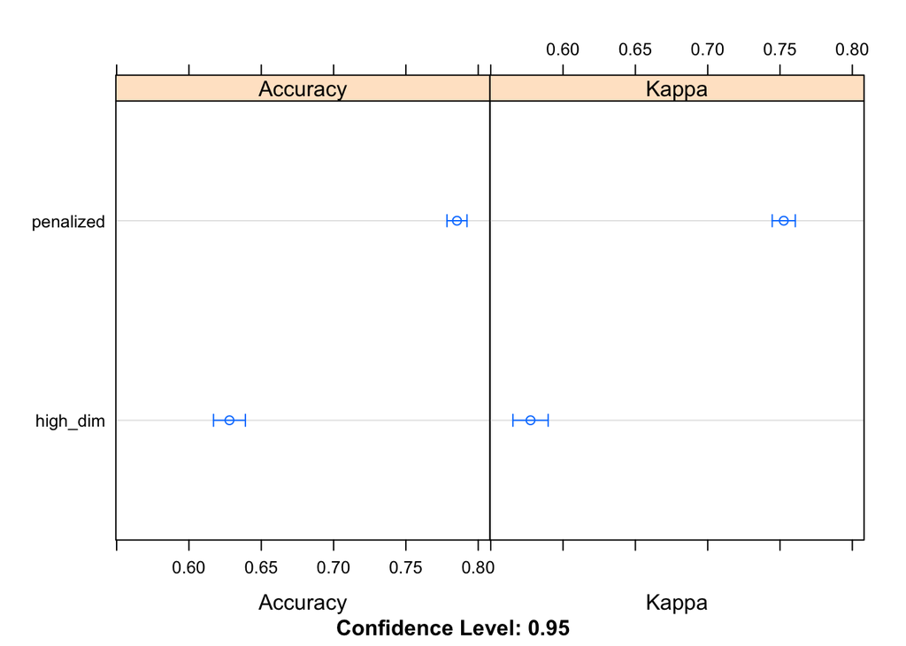

```r
dotplot(resamples(list(high_dim = hdda_model,
                       penalized = pda_model)))
```

In the training samples, the high-dimensional discrimanant analysis had a cross-validation accuracy of 62.8%, and the penalized discriminant analysis had a cross-validation accuracy of 78.5%. In the holdout data set, the accuracies were 59.6% and 60.6% in the high-dimensional and penalized discriminant analyses respectively. While I think that either model is reasonable, I would probably select the penalized discriminant analysis as both its training and holdout accuracy is slightly higher. Overall, I think that there is a relationship between how a person writes and his or her MBTI type. A classification accuracy of roughly 60% is good for a 16 class classification problem especially based on natural language processing. A larger sample might allow for an even higher classification accuracy.

# Visualization

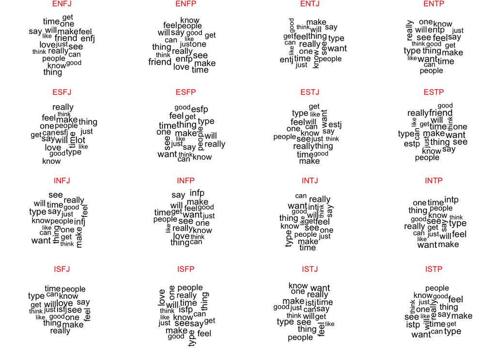

```r
# Define function to create wordcloud
createWC <- function(type){
  tbl <- mbti_full[which(mbti_combined$MBTI_type == type), ]
  wc_tbl <- data.frame(word = colnames(tbl),
                      freq = colSums(tbl))
  wordcloud(wc_tbl$word, wc_tbl$freq,
            max.words = 20,
            scale = c(.8,1.4))
}

# Plot 4 by 4 grid of wordclouds for each MBTI Type
layout(matrix(c(1:16), nrow=4, byrow=TRUE), heights=rep(2, 16))
par(mar=rep(0, 4))
for(i in c("ENFJ", "ENFP", "ENTJ", "ENTP", "ESFJ", "ESFP", "ESTJ", "ESTP",
           "INFJ", "INFP", "INTJ", "INTP", "ISFJ", "ISFP", "ISTJ", "ISTP")){
  createWC(i)
  text(.5, 1, i, col = "red")
}
```